# Teenage Pregnancy in Malawi: Risk Factor and Spatial Analysis

B.Banda

Malawi MICS 2019-2020

# PART I: Background and Methods

## Study Overview / Background

Adolescent pregnancy remains a pressing global public health concern, with an estimated 16 million girls aged 15-19 giving birth each year, the majority in low- and middle-income countries. In Malawi, teenage pregnancy carries serious consequences for maternal and child health, education, and socioeconomic mobility. Despite national efforts to expand reproductive health services and adolescent-friendly programming, the prevalence of teenage pregnancy remains high, and substantial geographic variation persists across districts and sub-district administrative units.

This analysis uses the 2019-2020 Malawi Multiple Indicator Cluster Survey (MICS) to (i) quantify the prevalence of teenage pregnancy among adolescent females (15-19 years) and identify socio-demographic and economic risk factors using survey-weighted logistic regression, and (ii) characterise the spatial distribution of teenage pregnancy at the Traditional Authority (TA) level using global and local indicators of spatial autocorrelation to identify hotspots and coldspots.

## Methods

This study used data from the 2019-2020 Malawi MICS, a nationally representative household survey conducted by the National Statistical Office with support from UNICEF. The MICS employed a two-stage stratified cluster sampling design: enumeration areas (clusters) were selected within geographic strata (district x urbanicity combinations), and households were then selected by systematic sampling within each cluster. The survey collected data from 25,626 women aged 15-49 across 1,111 enumeration area clusters.

### Survey Design Specification

To properly account for the complex sampling structure, a survey design object was constructed in R specifying the primary sampling unit (HH1, the enumeration area cluster), strata (39 district x urbanicity combinations), and individual woman weights (`wmweight`), with clusters nested within strata (`nest = TRUE`). Individual weights ranged from 0.089 to 16.026 (mean = 2.01), indicating a non-self-weighting design requiring statistical adjustment.

### Spatial Analysis

Individual pregnancy status and survey weights were linked to cluster identifiers (HH1) and Traditional Authority (TA) names via the GPS cluster dataset (`MalawiMICS2019-20GPS.shp`). After merging, 1,095 clusters mapped to 333 unique Traditional Authorities. To account for GPS jittering applied in MICS for confidentiality (+/- 2-10 km urban, +/- 5 km rural), prevalence estimates were aggregated to the TA level. For each TA we computed the survey-weighted prevalence of pregnancy, 95% confidence intervals, unweighted sample size, and count of pregnant teens. TAs with fewer than 10 teen respondents were flagged as “very small” and those with 10-19 respondents as “small,” but all TAs with at least one respondent were retained to avoid selection bias.

TA boundary polygons were obtained from `mics_boundaries_nr.shp`. Polygons were aggregated to one geometry per unique TA name using spatial union (TA Nkula was excluded due to topology errors; final n = 331 unique TAs in WGS84). Prevalence values were standardised using Z-score transformation prior to spatial statistical testing.

Spatial relationships were defined using K-nearest neighbours (KNN-5) based on TA centroids, with row-standardised weights (style = `"W"`). Global Moran’s I was tested using both the asymptotic test (assuming normality) and a Monte Carlo permutation test (999 simulations). Local Indicators of Spatial Association (LISA) were computed for each TA, classifying each into High-High (Hotspot), Low-Low (Coldspot), High-Low or Low-High (Spatial Outlier), or Not Significant categories based on quadrant position and statistical significance (alpha = 0.05).

### Statistical Software

All analyses were performed in R (version 4.4.0). Survey-weighted descriptive and inferential statistics were computed with the `survey` package (Lumley, 2024) and `srvyr`. Data manipulation and tabulation used `tidyverse`, `haven`, `janitor`, `scales`, `gtsummary`, and `gt`. Spatial preprocessing, autocorrelation statistics, and mapping used `sf`, `spdep`, `sfdep`, `ggplot2`, `patchwork`, and `ggspatial`. Missingness was visualised with `mice::md.pattern()` (no imputation was performed; see Section 6). All tables and plots are generated reproducibly from this R Markdown document.

## Exposure Variables

The pre-specified exposures examined in the multivariable model (Table 3, Model 2) were:

- **Education**: Primary or lower (reference) vs. Secondary or higher
- **Wealth Index**: Richest (reference), Fourth, Middle, Second, Poorest (derived from household asset ownership and housing characteristics)
- **Place of Residence**: Urban (reference) vs. Rural
- **Marital status**: No - not in union (reference), Yes - currently married, Yes - living with partner
- **Contraceptive use**: No (reference) vs. Yes (currently using any contraceptive method)
- **Health insurance**: No (reference) vs. Yes

An additional exposure, *Ever had sex* (No vs. Yes), is reported in the descriptive Table 2 but excluded from the multivariable model on conceptual grounds: sexual debut sits on the causal pathway between sociodemographic exposures and pregnancy and would induce overadjustment bias if included alongside the upstream exposures. All exposures are treated as categorical, with reference categories chosen *a priori* based on the most-protected or modal stratum.

## Outcome Variable

The primary outcome is teenage pregnancy, defined among females aged 15-19 in the MICS Women’s dataset as any respondent who reported having ever given birth (CM1 = 1) OR currently being pregnant. This composite outcome captures both past pregnancy experience and current pregnancy status, reflecting the full burden of adolescent fertility in this age group.

# PART II: Data Preparation

## 1. Load Required Packages

We used the following packages in our analysis to enable data manipulation, survey-weighted estimation, publication-quality tables, multiple imputation, spatial analysis, and visualization. The pacman package manager automatically installs any missing packages and loads them into the R environment.

```r
# Load required packages using pacman for convenience
pacman::p_load(
  # Data manipulation and utilities
  data.table, tidyverse, purrr, haven, janitor, labelled,

  # Survey analysis and weighted estimation
  survey, srvyr,

  # Publication tables and formatting
  gtsummary, gt, kableExtra, knitr,

  # Spatial analysis and mapping
  sf, sfdep, spdep, leaflet, ggspatial, ggrepel,

  # Visualization
  ggplot2, patchwork,

  # Statistical methods
  mice,

  # Other utilities
  DiagrammeR
)
```

## 2. Read Women’s Dataset and Select Variables

We imported the MICS 2019–20 Women’s dataset from an SPSS (.sav) file and restricted the sample to adolescent females aged 15–19, retaining only the variables required for analysis: cluster identifier, household number, birth history, pregnancy status, age, education, urbanicity, marital status, health insurance, contraceptive use, sexual activity, sampling weight, wealth index, and stratum.

```r
WM <- read_sav("wm.sav") %>%
  clean_names()

wm_small <- WM %>%
  filter(wb4 >= 15 & wb4 <= 19) %>%
  select(
    hh1, hh2, cm1, cp1, wb3m, wb3y, wb4, wb6a, wb14, wb16, wb17, wb18,
    cp3, ma11, sb1, wmweight, windex5, ma1, stratum
  )
```

## 3. Open MICS Shapefile and GIS Data

We loaded two spatial datasets: the GPS cluster shapefile containing enumeration area coordinates (`MalawiMICS2019-20GPS.shp`), which links each cluster to its geographic location and Traditional Authority name (`GEONAMET`), and the TA boundary polygons (`mics_boundaries_nr.shp`) used for choropleth mapping and spatial analysis.

```r
sf_data <- st_read("MalawiMICS2019-20GPS.shp")

# 2) Read
sf_mics_boundaries <- st_read("mics_boundaries_nr.shp", quiet = TRUE)

#sf_mics_boundaries_2 <- st_read ("1mics_boundaries_nr.shp", queit = TRUE)
```

## 4. Derive Analytic Variables (`wm_clean`)

We recoded all raw MICS variables into analysis-ready categorical variables, including the composite teenage pregnancy outcome (ever given birth OR currently pregnant), education level (primary or lower vs. secondary or higher), wealth index quintile, urbanicity, marital status, health insurance coverage, contraceptive use, and sexual history. All factor levels were explicitly defined to ensure consistent ordering in tables and models.

```r
wm_clean <- wm_small %>%
  mutate(
    # Ever given birth
    ever_given_birth = case_when(
      cm1 == 1 ~ "Yes",
      cm1 == 2 ~ "No",
      TRUE ~ NA_character_
    ),

    # Wealth index quintile
    wealth_index = factor(case_when(
      windex5 == 1 ~ "Poorest",
      windex5 == 2 ~ "Second",
      windex5 == 3 ~ "Middle",
      windex5 == 4 ~ "Fourth",
      windex5 == 5 ~ "Richest"
    ), levels = c("Poorest", "Second", "Middle", "Fourth", "Richest")),

    # Current pregnancy
    cur_pregnant = case_when(
      cp1 == 1 ~ "Yes",
      cp1 == 2 ~ "No",
      TRUE ~ NA_character_
    ),

    current_marital = case_when(
      ma1 == 1 ~ "Yes - currently married",
      ma1 == 2 ~ "Yes - living with partner",
      ma1 == 3 ~ "No - not in union",
      TRUE     ~ NA_character_
    ),

    # Education level (3 categories)
    Edu_level = case_when(
      wb6a %in% c(0) ~ "Primary or lower",
      wb6a %in% c(1) ~ "Primary or lower",
      wb6a %in% c(2:5) ~ "Secondary or higher",
      TRUE ~ NA_character_
    ),

    # Urbanicity
    urbanicity = case_when(
      wb16 %in% c(1, 2) ~ "Urban",
      wb16 == 3 ~ "Rural",
      TRUE ~ NA_character_
    ),

    # Health insurance
    insurance = case_when(
      wb18 == 1 ~ "Yes",
      wb18 == 2 ~ "No",
      TRUE ~ NA_character_
    ),

    # Contraceptive use
    contraceptive_use = case_when(
      cp3 == 1 ~ "Yes",
      cp3 == 2 ~ "No",
      TRUE ~ NA_character_
    ),

    # Ever had sex
    had_sex = case_when(
      sb1 >= 8 & sb1 <= 19 ~ "Yes",
      sb1 == 0 ~ "No",
      TRUE ~ NA_character_
    ),

    # Teen pregnancy (derived outcome)
    teen_pregnancy = case_when(
      cur_pregnant == "Yes" | ever_given_birth == "Yes" ~ "Yes",
      cur_pregnant == "No" & ever_given_birth == "No" ~ "No",
      TRUE ~ NA_character_
    )
  )
```

## 5. Merge Women’s Dataset with Cluster GIS Data

We joined the cleaned women’s dataset (`wm_clean`) to the GPS cluster shapefile on the cluster identifier (`HH1`), creating a spatially-referenced analytical dataset (`sf_joined`) that retains point geometry for each respondent’s cluster. We verified that coordinate reference systems were aligned before merging and flagged urbanicity as a factor variable. The merged object was saved as an RDS file for use in downstream mapping and spatial regression steps.

```r
# ===============================================================
# Load and Merge MICS Spatial and Survey Data
# ===============================================================

# --- 1. Define main data directory ---
data_dir <- "C:/Users/b.banda/Box/Teenage pregnancy/Lit review Matrix Table/MICS_Analysis/MICS_Analysis"

# --- 2. Read cluster GPS shapefile ---
mics_clusters_sf <- st_read(file.path(data_dir, "MalawiMICS2019-20GPS.shp"), quiet = TRUE)

# --- 3. Read boundary shapefile (district or T/A polygons) ---
mics_boundaries_sf <- st_read(file.path(data_dir, "mics_boundaries/mics_boundaries_nr.shp"), quiet = TRUE)

# --- 4. Check and align coordinate reference systems (CRS) ---
if (st_crs(mics_clusters_sf) != st_crs(mics_boundaries_sf)) {
  mics_clusters_sf <- st_transform(mics_clusters_sf, st_crs(mics_boundaries_sf))
}

# ===============================================================
# 🔹 Merge Women’s Data (wm_clean) with Cluster Spatial Data
# ===============================================================

# ⚠️ Ensure HH1 matches the cluster ID variable in the shapefile
# If your shapefile has a different ID column (e.g., CLUSTERID), adjust the join key
sf_joined <- mics_clusters_sf %>%
  right_join(wm_clean, by = c("HH1" = "hh1")) %>%
  mutate(
    # Create a unique ID for later weighting or identification
    id = sprintf("WM_%04d", row_number()),

    # Ensure urbanicity is a proper factor (already derived earlier)
    urbanicity = factor(urbanicity, levels = c("Urban", "Rural"))
  )

# ===============================================================
# 🔹 Quick Data Check
# ===============================================================
sf_joined %>%
  st_drop_geometry() %>%
  count(HH6)
```

| HH6 | n |
| --- | --- |
| Rural | 4860 |
| Urban | 910 |

```r
# ===============================================================
# 🔹 Save for later steps (mapping, Moran’s I, regression)
# ===============================================================
saveRDS(sf_joined, file.path(data_dir, "sf_joined_cleaned.RDS"))
```

## 6. Check Missingness

We assessed missing data patterns across all key analysis variables using both unweighted counts and survey-weighted proportions. We visualized the missing data pattern using `mice::md.pattern()` and produced a summary table reporting the number and percentage of missing values before and after applying sampling weights. This step informed decisions about whether multiple imputation was warranted for any variable.

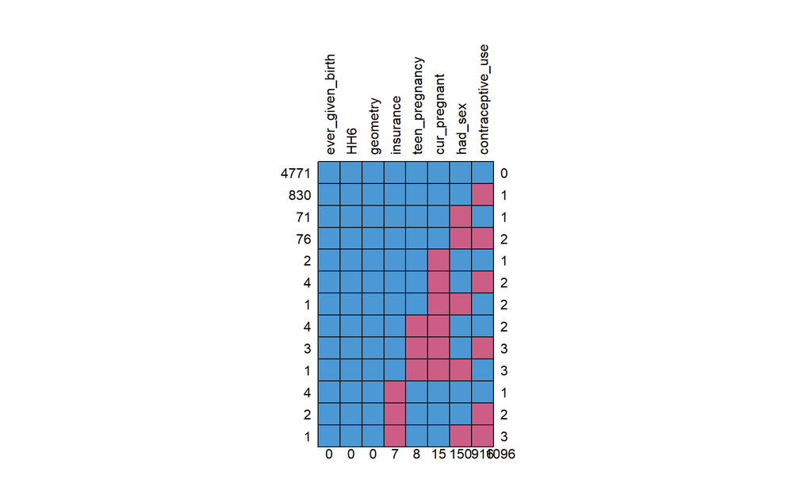

```
##      ever_given_birth HH6 geometry insurance teen_pregnancy cur_pregnant
## 4771                1   1        1         1              1            1
## 830                 1   1        1         1              1            1
## 71                  1   1        1         1              1            1
## 76                  1   1        1         1              1            1
## 2                   1   1        1         1              1            0
## 4                   1   1        1         1              1            0
## 1                   1   1        1         1              1            0
## 4                   1   1        1         1              0            0
## 3                   1   1        1         1              0            0
## 1                   1   1        1         1              0            0
## 4                   1   1        1         0              1            1
## 2                   1   1        1         0              1            1
## 1                   1   1        1         0              1            1
##                     0   0        0         7              8           15
##      had_sex contraceptive_use
## 4771       1                 1    0
## 830        1                 0    1
## 71         0                 1    1
## 76         0                 0    2
## 2          1                 1    1
## 4          1                 0    2
## 1          0                 1    2
## 4          1                 1    2
## 3          1                 0    3
## 1          0                 1    3
## 4          1                 1    1
## 2          1                 0    2
## 1          0                 0    3
##          150               916 1096
```

```r
# ==========================================================
# 🔹 Missingness Analysis for Key Variables
# ==========================================================

# 1. Variables to assess
vars_for_missing <- c(
  "ever_given_birth", "cur_pregnant", "HH6", "insurance",
  "contraceptive_use", "had_sex", "teen_pregnancy", "edu_level", "wmweight"
)

# 2. Subset and standardize
dt_miss <- sf_joined %>%
  select(any_of(vars_for_missing)) %>%
  mutate(
    across(where(is.character) | where(is.logical), as.factor),
    wmweight = suppressWarnings(as.numeric(wmweight))
  )

# 3. Visualize missing data pattern (unweighted)
ok_for_mice <- dt_miss %>%
  select(-wmweight) %>%
  mutate(across(where(is.factor), ~ as.numeric(.x)))

mice::md.pattern(ok_for_mice, rotate.names = TRUE)
```

```r
# 4. Weighted missingness summary
total_w <- sum(dt_miss$wmweight, na.rm = TRUE)
if (total_w == 0) stop("Survey weights are missing or all zero.")

miss_tbl <- tibble(variable = vars_for_missing) %>%
  mutate(
    n_missing     = map_int(variable, ~ sum(is.na(dt_miss[[.x]]))),
    pct_missing   = round(100 * n_missing / nrow(dt_miss), 1),
    w_missing     = map_dbl(variable, ~ sum(dt_miss$wmweight[is.na(dt_miss[[.x]])], na.rm = TRUE)),
    w_pct_missing = round(100 * w_missing / total_w, 1)
  ) %>%
  arrange(desc(w_pct_missing))

# 5. Display clean summary table
miss_tbl %>%
  gt() %>%
  fmt_number(columns = c(pct_missing, w_pct_missing), decimals = 1) %>%
  tab_header(title = "Weighted and Unweighted Missingness Summary") %>%
  cols_label(
    variable = "Variable",
    n_missing = "N Missing (Unweighted)",
    pct_missing = "% Missing (Unweighted)",
    w_missing = "Weighted N Missing",
    w_pct_missing = "% Missing (Weighted)"
  )
```

Weighted and Unweighted Missingness Summary

| Variable | N Missing (Unweighted) | % Missing (Unweighted) | Weighted N Missing | % Missing (Weighted) |
| --- | --- | --- | --- | --- |
| contraceptive_use | 916 | 15.9 | 831.10292 | 15.0 |
| had_sex | 150 | 2.6 | 130.46318 | 2.4 |
| cur_pregnant | 15 | 0.3 | 18.66620 | 0.3 |
| teen_pregnancy | 8 | 0.1 | 10.56066 | 0.2 |
| insurance | 7 | 0.1 | 7.50538 | 0.1 |
| ever_given_birth | 0 | 0.0 | 0.00000 | 0.0 |
| HH6 | 0 | 0.0 | 0.00000 | 0.0 |
| edu_level | 0 | 0.0 | 0.00000 | 0.0 |
| wmweight | 0 | 0.0 | 0.00000 | 0.0 |

## 7. Set Reference Categories and Master Variable Configuration

To ensure consistency across all descriptive tables and regression models, we define a single master configuration specifying: (i) factor levels with explicit reference categories ordered first, (ii) standardised variable labels used across all output tables, and (iii) the canonical variable order followed in Tables 1–3. Setting reference categories at the data-preparation stage—rather than at the modelling stage—guarantees that descriptive tables and odds ratios use identical orderings, simplifies interpretation, and prevents discrepancies between the prevalence tables and the multivariable models. Reference categories were chosen *a priori* based on conceptual considerations (typically the most-protected or most-prevalent category) to align with prior literature on adolescent fertility in sub-Saharan Africa.

```r
# ============================================================
# Master Configuration: Variable Levels, Labels, and Order
# ============================================================
# This block is the single source of truth for variable handling
# throughout the manuscript tables.
# ------------------------------------------------------------

# 1) Reference categories (placed first within each factor)
# ------------------------------------------------------------
# - Edu_level         : "Primary or lower" (modal, lowest education)
# - wealth_index      : "Richest" (highest SES, conceptually protected)
# - HH6               : "Urban" (lower-prevalence residence stratum)
# - current_marital   : "No - not in union" (modal, baseline marital state)
# - insurance         : "No" (most prevalent / unexposed baseline)
# - contraceptive_use : "No" (unexposed baseline)
# - had_sex           : "No" (unexposed baseline)
# ------------------------------------------------------------

sf_joined <- sf_joined %>%
  mutate(
    teen_pregnancy   = factor(teen_pregnancy, levels = c("No", "Yes")),
    Edu_level        = factor(Edu_level,
                              levels = c("Primary or lower", "Secondary or higher")),
    wealth_index     = factor(wealth_index,
                              levels = c("Richest", "Fourth", "Middle", "Second", "Poorest")),
    HH6              = factor(HH6,
                              levels = c("Urban", "Rural")),
    current_marital  = factor(current_marital,
                              levels = c("No - not in union",
                                         "Yes - currently married",
                                         "Yes - living with partner")),
    insurance        = factor(insurance,        levels = c("No", "Yes")),
    contraceptive_use = factor(contraceptive_use, levels = c("No", "Yes")),
    had_sex          = factor(had_sex,          levels = c("No", "Yes"))
  )

# 2) Master label map (single source of truth across all tables)
# ------------------------------------------------------------
master_labels <- c(
  Edu_level         = "Education",
  wealth_index      = "Wealth Index",
  HH6               = "Place of Residence",
  current_marital   = "Marital status",
  contraceptive_use = "Contraceptive use",
  insurance         = "Health insurance",
  had_sex           = "Ever had sex"
)

# 3) Canonical variable order across Tables 1, 2, 3
# ------------------------------------------------------------
master_order <- c(
  "Edu_level",
  "wealth_index",
  "HH6",
  "current_marital",
  "contraceptive_use",
  "insurance"
)

# 4) Master factor-level lookup (kept here for downstream label-aware loops)
# ------------------------------------------------------------
master_levels <- list(
  Edu_level         = c("Primary or lower", "Secondary or higher"),
  wealth_index      = c("Richest", "Fourth", "Middle", "Second", "Poorest"),
  HH6               = c("Urban", "Rural"),
  current_marital   = c("No - not in union", "Yes - currently married", "Yes - living with partner"),
  contraceptive_use = c("No", "Yes"),
  insurance         = c("No", "Yes"),
  had_sex           = c("No", "Yes")
)
```

## 8. Create Survey Design Object

We specified the complex survey design using `svydesign()`, defining enumeration area clusters (`HH1`) as the primary sampling unit, district-by-urbanicity combinations as the stratification variable (`stratum`), and individual woman sampling weights (`wmweight`). Setting `nest = TRUE` accounts for cluster identifiers being nested within strata. This design object (`mics_svy`) underpins all survey-weighted prevalence estimates, chi-square tests, and logistic regression models in Parts III and IV. The design carries the factor-level orderings defined above, ensuring reference categories appear first in every downstream table.

```r
mics_svy <- svydesign(
  id      = ~HH1,
  strata  = ~stratum,
  weights = ~wmweight,
  data    = sf_joined,
  nest    = TRUE
)

# Quick verification: confirm reference levels are first
cat("Verification of reference categories (first level of each factor):\n")
```

```
## Verification of reference categories (first level of each factor):
```

```r
purrr::walk(master_order, function(v) {
  lvls <- levels(mics_svy$variables[[v]])
  cat(sprintf("  %-20s reference = %s\n", v, lvls[1]))
})
```

```
##   Edu_level            reference = Primary or lower
##   wealth_index         reference = Richest
##   HH6                  reference = Urban
##   current_marital      reference = No - not in union
##   contraceptive_use    reference = No
##   insurance            reference = No
```

## 9. Helper Functions for Survey-weighted Tables

We defined a set of reusable helper functions to streamline survey-weighted estimation throughout the analysis. `svyciprop_fun()` computes a survey-weighted proportion with likelihood-based 95% confidence intervals for a single variable level. `svyciprop_by_fun()` extends this to stratified estimates. `style_pvalue2()` formats p-values to publication standard. `model_log()`, `model_lin()`, and `model_pois()` are wrappers around `svyglm()` for logistic, linear, and Poisson regression under the complex survey design. `add_significance_stars()` is used downstream to format `gtsummary` regression tables with conventional significance markers (*p<0.05; **p<0.01;*** p<0.001).

```r
# Thousands-formatting helper used in all table footers and headers
comma <- function(x) format(x, big.mark = ",", scientific = FALSE)

# Significance-stars helper for gtsummary regression tables
add_significance_stars <- function(tbl,
                                   pattern = "{estimate} [{conf.low}-{conf.high}]{stars}",
                                   hide_p  = TRUE,
                                   hide_se = TRUE) {
  tbl <- tbl %>%
    modify_table_body(
      ~ .x %>%
        mutate(
          stars = case_when(
            !is.na(p.value) & p.value < 0.001 ~ "***",
            !is.na(p.value) & p.value < 0.01  ~ "**",
            !is.na(p.value) & p.value < 0.05  ~ "*",
            TRUE                              ~ ""
          )
        )
    ) %>%
    modify_column_merge(pattern = pattern, rows = !is.na(estimate))

  if (hide_p  && "p.value"   %in% names(tbl$table_body)) tbl <- tbl %>% modify_column_hide(columns = p.value)
  if (hide_se && "std.error" %in% names(tbl$table_body)) tbl <- tbl %>% modify_column_hide(columns = std.error)

  tbl
}

svyciprop_fun <- function(design, var, var_lvl) {
  # Build formula for indicator: e.g., I(gender == "Man")
  form <- paste0("I(", var, " == ", deparse(var_lvl), ")")

  # Compute the weighted proportion using svyciprop() with likelihood method
  svy_props <- svyciprop(
    as.formula(paste0("~", form)),
    design,
    method = "likelihood"
  )

  # Extract the proportion and confidence intervals, then scale to percentages
  prop <- svy_props[1]
  cil <- attr(svy_props, "ci")[1]
  ciu <- attr(svy_props, "ci")[2]

  df_out <- data.frame(
    var = var,
    lvl = var_lvl,
    est = prop,
    ci_l = cil,
    ci_u = ciu
  ) %>%
    mutate(
      est = est * 100,
      ci_l = ci_l * 100,
      ci_u = ci_u * 100
    )

  return(df_out)
}

svyciprop_by_fun <- function(.data, var, var_lvl, by) {
  form <- paste0("I(", var, " == ", deparse(var_lvl), ")")

  svy_props <- svyby(
    as.formula(paste0("~", form)),
    by = as.formula(paste0("~", by)),
    design = .data,
    svyciprop,
    vartype = "ci",
    method = "likelihood"
  ) %>%
    rename("est" = form) %>%
    mutate(
      var = var,
      lvl = var_lvl,
      lvl = factor(lvl, levels = var_lvl),
      est = est * 100,
      ci_l = ci_l * 100,
      ci_u = ci_u * 100
    )

  return(svy_props)
}

miss_svy <- function(.data, var, dkrf = TRUE) {
  na_len <- sum(is.na(.data[, var]))
  var_formal_lc <- var

  if (dkrf == TRUE) {
    .var <- sym(var)
    .data_sub <- filter(.data, !!.var %in% c("Don't know/Refused", "Not applicable"))
    dkrf_len <- sum(!is.na(.data_sub[, .var]))
    na_len <- na_len + dkrf_len
  }

  statement <- paste0("Participants missing ", var_formal_lc, " were removed (N = ", na_len, ").")
  return(statement)
}

style_pvalue2 <- function(x, digits = 2, prepend_p = FALSE,
                          big.mark = NULL, decimal.mark = ".", ...) {

  # Pre-allocate result vector
  p_fmt <- character(length(x))

  # Loop through each value in x
  for (i in seq_along(x)) {
    xi <- x[i]

    if (is.na(xi)) {
      p_fmt[i] <- NA_character_
    } else if (digits == 1) {
      p_fmt[i] <- dplyr::case_when(
        xi > 0.9 ~ paste0(">", format(0.9, digits = 1, nsmall = 1)),
        round(xi, 1) >= 0.2 ~ format(xi, digits = 1, nsmall = 1),
        round(xi, 2) >= 0.1 ~ format(xi, digits = 2, nsmall = 2),
        xi >= 0.001 ~ format(xi, digits = 3, nsmall = 3),
        xi < 0.001 ~ "<0.001"
      )
    } else if (digits == 2) {
      p_fmt[i] <- dplyr::case_when(
        xi > 0.99 ~ ">0.99",
        round(xi, 2) >= 0.1 ~ format(xi, digits = 2, nsmall = 2),
        xi >= 0.01 ~ format(xi, digits = 2, nsmall = 2),
        xi >= 0.001 ~ "<0.01",
        xi < 0.001 ~ "<0.001"
      )
    } else if (digits == 3) {
      p_fmt[i] <- dplyr::case_when(
        xi > 0.999 ~ ">0.999",
        xi >= 0.001 ~ format(xi, digits = 3, nsmall = 3),
        xi < 0.001 ~ "<0.001"
      )
    } else if (digits == 4) {
      p_fmt[i] <- dplyr::case_when(
        xi > 0.9999 ~ ">0.9999",
        xi >= 0.0001 ~ format(xi, digits = 4, nsmall = 4),
        xi < 0.0001 ~ "<0.0001"
      )
    } else {
      stop("The `digits=` argument must be 1, 2, 3, or 4.")
    }

    if (prepend_p && !is.na(p_fmt[i])) {
      if (startsWith(p_fmt[i], "<") || startsWith(p_fmt[i], ">")) {
        p_fmt[i] <- paste0("p", p_fmt[i])
      } else {
        p_fmt[i] <- paste0("p=", p_fmt[i])
      }
    }
  }

  return(p_fmt)
}

# Survey-weighted unadjusted logistic regression.
# Ensures correct standard errors under complex survey design.
model1 <- function(.data, outcome, ...) {
  .form <- as.formula(paste0(outcome, " ~ ", paste(..., collapse = "+")))
  svyglm(.form, design = .data, family = "quasibinomial")
}

# Survey-weighted linear regression for continuous outcomes.
# Accounts for weights, strata, and clustering in estimating means.
model_lin <- function(.data, outcome, ...) {
  .form <- as.formula(paste0(outcome, " ~ ", paste(..., collapse = "+")))
  svyglm(.form, design = .data, family = "gaussian")
}

# Survey-weighted logistic regression with multiple predictors.
# Returns robust estimates using the quasibinomial family.
model_log <- function(.data, outcome, ...) {
  .form <- as.formula(paste0(outcome, " ~ ", paste(..., collapse = "+")))
  svyglm(.form, design = .data, family = "quasibinomial")
}

# Poisson regression with survey weights for count data outcomes.
# Recommended for modeling counts like symptom scores or events.
model_pois <- function(.data, outcome, ...) {
  .form <- as.formula(paste0(outcome, " ~ ", paste(..., collapse = "+")))
  svyglm(.form, design = .data, family = "quasipoisson")
}
```

# PART III: Risk Factor Analysis - Final Tables

## Final Table 1: Sample Demographics

```r
# ============================================================
# Table 1: Sample Demographics by Teen Pregnancy Status
# ============================================================
# Uses master_order, master_labels, master_levels defined in Section 7.
# `comma()` and `add_significance_stars()` are defined in Section 9.
# Complete  Table 1 stratified by teen pregnancy


comma <- function(x) format(x, big.mark = ",", scientific = FALSE)

# # --- Variable levels and labels (excluding teen_pregnancy) ------------------
tls <- list(

  Edu_level         = c("Primary or lower","Secondary or higher"),
  HH6               = c("Rural", "Urban"),
  insurance         = c("No", "Yes"),
  contraceptive_use = c("No", "Yes"),
  wealth_index      = c("Poorest", "Second", "Middle", "Fourth", "Richest"),
  current_marital   = c("Yes - currently married", "Yes - living with partner", "No - not in union"))

# Define variable label mapping
var_labels <- c(
  Edu_level          = "Education Level",
  HH6                = "Urbanicity",
  wealth_index       = "Wealth Index",
  current_marital    = "Current Marital Status",
   contraceptive_use  = "Contraceptive Use",
   insurance          = "Health Insurance Coverage",
  ever_given_birth   = "Ever Given Birth")

# Define total_n used in cols_label()
total_n <- nrow(mics_svy$variables)

# --- Overall (Total) column with unweighted counts --------------------------
overall_tbl <- map_dfr(
  names(var_labels),
  function(v) {
    lvls <- tls[[v]]
    if (length(lvls) == 0) {
      message("Warning: No valid levels for ", v)
      return(tibble(var = v, lvl = character(), est_tot = character(), n_tot = integer()))
    }
    prop <- map_dfr(lvls, ~ {
      res <- tryCatch(
        svyciprop_fun(mics_svy, v, .x),
        error = function(e) {
          message("Warning: svyciprop_fun failed for ", v, "=", .x, ": ", e$message)
          return(tibble(est = NA, ci_l = NA, ci_u = NA))
        }
      )
      res %>% mutate(lvl = .x)
    })
    count <- map_dfr(lvls, ~ {
      dat <- mics_svy$variables
      n <- sum(dat[[v]] == .x, na.rm = TRUE)
      tibble(lvl = .x, n_tot = n)
    })
    prop %>%
      left_join(count, by = "lvl") %>%
      mutate(var = v, lvl = factor(lvl, levels = lvls)) %>%
      arrange(lvl) %>%
      mutate(
        est_tot = case_when(
          is.na(est) | is.na(ci_l) | is.na(ci_u) ~ sprintf("NA (%s) [NA, NA]", comma(n_tot)),
          TRUE ~ sprintf("%0.1f%% (%s) [%0.1f%%, %0.1f%%]", est, comma(n_tot),  ci_l, ci_u)
        )
      ) %>%
      select(var, lvl, est_tot, n_tot)
  }
)

# --- Stratified by teen_pregnancy (No/Yes) with unweighted counts -----------
by_tbl <- map_dfr(
  names(var_labels),
  function(v) {
    lvls <- tls[[v]]
    if (length(lvls) == 0) {
      message("Warning: No valid levels for ", v)
      return(tibble(var = v, lvl = character(), No = character(), Yes = character(), n_no = integer(), n_yes = integer()))
    }
    prop <- map_dfr(lvls, ~ {
      lv <- .x
      fstr <- paste0("I(", v, " == \"", lv, "\")")
      out <- tryCatch(
        {
          res <- svyby(
            as.formula(paste0("~", fstr)),
            ~teen_pregnancy,
            mics_svy,
            svyciprop,
            method = "logit",
            vartype = "ci",
            na.rm = TRUE,
            keep.names = TRUE
          )
          names(res)[names(res) == fstr] <- "est"
          names(res)[names(res) == paste0(fstr, ".lower")] <- "ci_l"
          names(res)[names(res) == paste0(fstr, ".upper")] <- "ci_u"
          res
        },
        error = function(e) {
          message("Warning: svyby failed for ", v, "=", lv, " by teen_pregnancy: ", e$message)
          return(data.frame(teen_pregnancy = c("No", "Yes"),
                            est = NA, ci_l = NA, ci_u = NA))
        }
      )
      out %>%
        mutate(lvl = lv) %>%
        select(teen_pregnancy, lvl, est, ci_l, ci_u)
    })
    count <- map_dfr(lvls, ~ {
      dat <- mics_svy$variables
      n <- tapply(dat[[v]] == .x, dat[["teen_pregnancy"]], sum, na.rm = TRUE)
      data.frame(
        teen_pregnancy = names(n),
        lvl = .x,
        n = as.numeric(n)
      ) %>%
        filter(!is.na(teen_pregnancy))
    })
    prop %>%
      left_join(count, by = c("teen_pregnancy", "lvl")) %>%
      mutate(
        var = v,
        est_ci = case_when(
          is.na(est) | is.na(ci_l) | is.na(ci_u) ~ sprintf("NA (%s) [NA, NA]", comma(n)),
          TRUE ~ sprintf("%0.1f%% (%s) [%0.1f%%, %0.1f%%]", 100 * est, comma(n), 100 * ci_l, 100 * ci_u)
        )
      ) %>%
      select(var, lvl, teen_pregnancy, est_ci, n) %>%
      pivot_wider(names_from = teen_pregnancy, values_from = c(est_ci, n), values_fill = list(est_ci = "", n = 0)) %>%
      mutate(lvl = factor(lvl, levels = lvls)) %>%
      arrange(lvl) %>%
      rename(n_no = n_No, n_yes = n_Yes)
  }
)

# --- Combine & render table -------------------------------------------------
final_tbl <- overall_tbl %>%
  left_join(by_tbl, by = c("var", "lvl")) %>%
  mutate(var_label = var_labels[var],
         lvl = as.character(lvl)) %>%
  select(var_label, lvl, n_yes, Yes = est_ci_Yes,n_no, No = est_ci_No,n_tot, est_tot)

gt_tbl1_strat <- final_tbl %>%
  gt(groupname_col = "var_label") %>%
  tab_header(
    title = "Table 1: Sample demographics",
    subtitle = "Unweighted total N and survey-weighted percentages (95% CI), stratified by Teen Pregnancy"
  ) %>%
  cols_label(
    lvl = "Level",
    n_tot = "n",
    est_tot = html(paste0("Total (Unweighted n = ", comma(total_n), ")")),
    n_no = "n = 4,175",
    No = "Teen Pregnancy: No",
    n_yes = "n = 1,595",
    Yes = "Teen Pregnancy: Yes"
  ) %>%
  tab_footnote(
    footnote = "Estimates and confidence intervals are survey-weighted; 95% CIs use Rao–Scott adjustments where applicable.",
    locations = cells_title(groups = "title")
  ) %>%
  tab_options(
    table.font.size = px(13),
    heading.align = "left",
    column_labels.font.weight = "bold"
  )

# Display the table
gt_tbl1_strat
```

Table 1: Sample demographics<sup>1</sup>

Unweighted total N and survey-weighted percentages (95% CI), stratified by Teen Pregnancy

[output not shown]

<sup>1</sup> Estimates and confidence intervals are survey-weighted; 95% CIs use Rao–Scott adjustments where applicable.

## Supplementary Table S1: Survey-Weighted Chi-Square Tests

We tested the bivariate association between teenage pregnancy and each covariate using chi-square tests on survey-weighted contingency tables (`svytable()` + `chisq.test()`). This approach correctly propagates sampling weights into the cell counts without the matrix decomposition issues that can arise with Rao-Scott corrections on sparse multi-level variables. P-values below 0.05 are bolded to highlight statistically significant associations. Variables and labels follow the master configuration in Section 7.

```r
# ============================================================
# Supplementary Table S1: Survey-Weighted Chi-Square Tests
# ============================================================

chi_results <- map_dfr(master_order, function(v) {
  sub_design <- subset(mics_svy, !is.na(teen_pregnancy) & !is.na(get(v)))

  tab  <- svytable(as.formula(paste0("~teen_pregnancy + ", v)), design = sub_design)
  test <- chisq.test(tab)

  tibble(
    Variable = master_labels[v],
    Chi_sq   = as.numeric(test$statistic),
    df       = as.numeric(test$parameter),
    p_value  = test$p.value
  )
})

chi_results %>%
  gt() %>%
  tab_header(
    title    = md("**Supplementary Table S1.** Survey-weighted χ² tests of teenage pregnancy vs sociodemographic and behavioural covariates"),
    subtitle = md("Malawi MICS 2019–20")
  ) %>%
  fmt_number(columns = Chi_sq,  decimals = 2) %>%
  fmt_number(columns = df,      decimals = 0) %>%
  fmt(columns = p_value, fns = function(x) style_pvalue2(x, digits = 3)) %>%
  cols_label(
    Variable = "Covariate",
    Chi_sq   = md("χ² statistic"),
    df       = "df",
    p_value  = "p-value"
  ) %>%
  tab_style(
    style     = cell_text(weight = "bold"),
    locations = cells_body(columns = p_value, rows = p_value < 0.05)
  ) %>%
  tab_footnote(
    footnote  = paste(
      "Tests use Pearson χ² applied to survey-weighted contingency tables (svytable), which propagates sampling weights into cell counts under the complex MICS design.",
      "Bold p-values indicate significance at α = 0.05.",
      "Each test is restricted to respondents with non-missing values on both teenage pregnancy and the covariate."
    ),
    locations = cells_title(groups = "title")
  ) %>%
  tab_options(
    table.font.size           = px(13),
    heading.align             = "left",
    column_labels.font.weight = "bold"
  )
```

**Supplementary Table S1.** Survey-weighted χ² tests of teenage pregnancy vs sociodemographic and behavioural covariates<sup>1</sup>

Malawi MICS 2019–20

| Covariate | χ² statistic | df | p-value |
| --- | --- | --- | --- |
| Education | 164.49 | 1 | <0.001 |
| Wealth Index | 341.67 | 4 | <0.001 |
| Place of Residence | 81.87 | 1 | <0.001 |
| Marital status | 2,636.57 | 2 | <0.001 |
| Contraceptive use | 385.84 | 1 | <0.001 |
| Health insurance | 5.10 | 1 | 0.024 |

<sup>1</sup> Tests use Pearson χ² applied to survey-weighted contingency tables (svytable), which propagates sampling weights into cell counts under the complex MICS design. Bold p-values indicate significance at α = 0.05. Each test is restricted to respondents with non-missing values on both teenage pregnancy and the covariate.

## Final Table 2: Weighted Prevalence of Teenage Pregnancy

```r
# --- Variables for prevalence table
target_vars <- c(
  "Edu_level", "HH6","wealth_index",  "current_marital", "insurance",
 "contraceptive_use","had_sex"

)

var_labels <- c(
  ever_given_birth   = "Ever Given Birth",
  GEONAMES           = "District",
  cur_pregnant       = "Currently Pregnant",
  Edu_level          = "Education Level",
  HH6                = "Place of residence",
  insurance          = "Health Insurance Coverage",
  contraceptive_use  = "Contraceptive Use",
  wealth_index       = "Wealth Index",
  current_marital    = "Current Marital Status",
  had_sex            =  "Ever had sex"
)

# --- 1) Weighted prevalence of teen pregnancy (teen_pregnancy == "Yes")
prev_tbl <- map_dfr(target_vars, function(v) {
  dat <- mics_svy$variables
  lvls <- unique(na.omit(as.character(dat[[v]])))
  if (length(lvls) == 0) return(NULL)

  svy_res <- svyby(
    ~I(teen_pregnancy == "Yes"),
    as.formula(paste0("~", v)),
    mics_svy,
    svyciprop,
    vartype = "ci",
    method = "logit",
    na.rm = TRUE
  )

  est_col <- setdiff(names(svy_res), c(v, "ci_l", "ci_u", "se", "SE"))
  if (length(est_col) == 0) stop("No estimate column found.")

  svy_res %>%
    rename(est = all_of(est_col[1])) %>%
    mutate(
      var = v,
      lvl = as.character(!!sym(v)),
      est_ci = sprintf("%0.1f%% [%0.1f%%, %0.1f%%]",
                       100 * est, 100 * ci_l, 100 * ci_u)
    ) %>%
    select(var, lvl, est, ci_l, ci_u, est_ci)
}) %>%
  mutate(lvl = as.character(lvl))

# --- 2) Unweighted total counts for each level
unweighted_counts <- map_dfr(target_vars, function(v) {
  mics_svy$variables %>%
    filter(!is.na(.data[[v]])) %>%
    mutate(lvl = as.character(.data[[v]])) %>%
    count(lvl, name = "n_unweighted") %>%
    mutate(var = v)
})

# --- 3) NEW: Unweighted counts of teen pregnancy = "Yes"
teen_preg_counts <- map_dfr(target_vars, function(v) {
  mics_svy$variables %>%
    filter(!is.na(.data[[v]])) %>%
    mutate(lvl = as.character(.data[[v]])) %>%
    group_by(lvl) %>%
    summarise(
      n_teen_preg = sum(teen_pregnancy == "Yes", na.rm = TRUE),
      .groups = "drop"
    ) %>%
    mutate(var = v)
})

# --- 4) Merge counts + labels
prev_tbl_final <- prev_tbl %>%
  left_join(unweighted_counts, by = c("var", "lvl")) %>%
  left_join(teen_preg_counts, by = c("var", "lvl")) %>%
  mutate(var_label = var_labels[var]) %>%
  select(var_label, lvl, n_unweighted, n_teen_preg, est_ci)

# --- 5) Render as GT table
gt_prev_teen_pregnancy <- prev_tbl_final %>%
  gt(groupname_col = "var_label") %>%
  tab_header(
    title = "Table 2. Prevalence of Teenage Pregnancy by Sociodemographic Characteristics",
    subtitle = "Unweighted total N, unadjusted teen pregnancy counts, and survey-weighted % (95% CI)"
  ) %>%
  cols_label(
    lvl = "Level",
    n_unweighted = html(paste0("Total Participants (n = ", comma(nrow(mics_svy$variables)), ")")),
    n_teen_preg = "Teenage pregnancies (n= 1595)",
    est_ci = "Weighted % [95% CI]"
  ) %>%
  tab_footnote(
    footnote = paste(   "Source: Malawi Multiple Indicator Cluster Survey (MICS) 2019–20, women's questionnaire.",
      "Teen pregnancy defined as ever having given birth (CM1 = 1) or being currently pregnant (CP1 = 1).",
      " Estimates and confidence intervals are survey-weighted; 95% CIs use Rao–Scott adjustments, accounting for the two-stage stratified cluster design."
    )
,
    locations = cells_title(groups = "title")
  ) %>%
  tab_options(
    table.font.size = px(13),
    heading.align = "left",
    column_labels.font.weight = "bold"
  )

gt_prev_teen_pregnancy
```

Table 2. Prevalence of Teenage Pregnancy by Sociodemographic Characteristics<sup>1</sup>

Unweighted total N, unadjusted teen pregnancy counts, and survey-weighted % (95% CI)

| Level | Total Participants (n = 5,770) | Teenage pregnancies (n= 1595) | Weighted % [95% CI] |
| --- | --- | --- | --- |
| Education Level |  |  |  |
| Primary or lower | 3915 | 1255 | 31.5% [29.4%, 33.6%] |
| Secondary or higher | 1753 | 276 | 14.7% [12.5%, 17.3%] |
| Place of residence |  |  |  |
| Urban | 910 | 147 | 15.3% [11.8%, 19.5%] |
| Rural | 4860 | 1448 | 29.6% [27.8%, 31.5%] |
| Wealth Index |  |  |  |
| Richest | 1344 | 174 | 10.3% [8.4%, 12.7%] |
| Fourth | 1272 | 290 | 24.0% [20.9%, 27.5%] |
| Middle | 1145 | 326 | 28.1% [25.0%, 31.5%] |
| Second | 1035 | 357 | 33.7% [29.8%, 37.9%] |
| Poorest | 974 | 448 | 42.8% [38.4%, 47.4%] |
| Current Marital Status |  |  |  |
| No - not in union | 4602 | 564 | 11.4% [10.2%, 12.8%] |
| Yes - currently married | 1027 | 907 | 86.9% [83.6%, 89.5%] |
| Yes - living with partner | 141 | 124 | 88.4% [78.3%, 94.1%] |
| Health Insurance Coverage |  |  |  |
| No | 5748 | 1593 | 27.3% [25.6%, 29.0%] |
| Yes | 15 | 1 | 3.3% [0.1%, 49.4%] |
| Contraceptive Use |  |  |  |
| No | 4630 | 682 | 14.5% [13.0%, 16.1%] |
| Yes | 224 | 156 | 65.7% [56.2%, 74.0%] |
| Ever had sex |  |  |  |
| No | 2935 | 0 | 0.0% [0.0%, 0.0%] |
| Yes | 2685 | 1467 | 54.1% [51.3%, 56.8%] |

<sup>1</sup> Source: Malawi Multiple Indicator Cluster Survey (MICS) 2019–20, women's questionnaire. Teen pregnancy defined as ever having given birth (CM1 = 1) or being currently pregnant (CP1 = 1). Estimates and confidence intervals are survey-weighted; 95% CIs use Rao–Scott adjustments, accounting for the two-stage stratified cluster design.

## Final Table 3: Survey-weighted Logistic Regression

We estimated associations between each exposure and teenage pregnancy using survey-weighted logistic regression (`svyglm`, quasibinomial family) under two specifications: Model 1 reports unadjusted odds ratios from separate univariable models for each covariate; Model 2 reports adjusted odds ratios from a single multivariable model including all covariates. Reference categories follow the master configuration in Section 7. The multivariable model uses complete cases on all included covariates; the analytic sample size is reported in the table footer.

```r
# ============================================================
# Table 3: Logistic Regression of Teenage Pregnancy
# Among Adolescent Females (15–19 Years), Malawi MICS 2019–20
# ============================================================
# Reference categories and variable order are inherited from
# the master configuration in Section 7. Only the binary
# numeric outcome is created here.
# ------------------------------------------------------------

# Update design to add binary numeric outcome
mics_svy <- update(mics_svy, teen_pregnancy_num = as.numeric(teen_pregnancy == "Yes"))

# Helper: gtsummary label list (formula form) for adjusted model
full_label_list <- map2(master_order, master_labels[master_order],
                        ~ as.formula(paste0(.x, " ~ '", .y, "'")))

# Helper: single-variable label for univariable models
make_single_label <- function(var) {
  stats::setNames(list(master_labels[[var]]), var)
}

# ------------------------------------------------------------
# Step 1: Univariable (Model 1) survey-weighted logistic models
# ------------------------------------------------------------
unadj_models <- map(master_order, function(v) {
  svyglm(
    as.formula(paste0("teen_pregnancy_num ~ ", v)),
    design = mics_svy,
    family = quasibinomial()
  )
}) %>% set_names(master_order)

# ------------------------------------------------------------
# Step 2: Multivariable (Model 2) adjusted survey-weighted model
# Restricted internally by svyglm to complete cases on all
# covariates plus the outcome.
# ------------------------------------------------------------
adj_formula <- as.formula(
  paste0("teen_pregnancy_num ~ ", paste(master_order, collapse = " + "))
)
adj_model_full <- svyglm(adj_formula, design = mics_svy, family = quasibinomial())

# Analytic sample size of the adjusted model (complete cases)
adj_n_unweighted <- length(adj_model_full$residuals)
adj_n_weighted   <- ceiling(sum(mics_svy$variables$wmweight[
  rowSums(is.na(mics_svy$variables[, c("teen_pregnancy_num", master_order)])) == 0
], na.rm = TRUE))

# ------------------------------------------------------------
# Step 3: Format Model 1 (unadjusted ORs)
# ------------------------------------------------------------
unadj_tp_log <- map(
  master_order,
  function(j) {
    unadj_models[[j]] %>%
      tbl_regression(
        exponentiate = TRUE,
        intercept    = FALSE,
        pvalue_fun   = ~ style_pvalue2(.x, digits = 2),
        label        = make_single_label(j)
      ) %>%
      add_significance_stars(
        pattern = "{estimate} [{conf.low}-{conf.high}]{stars}",
        hide_p  = TRUE,
        hide_se = TRUE
      )
  }
) %>%
  tbl_stack()

# ------------------------------------------------------------
# Step 4: Format Model 2 (adjusted aORs)
# ------------------------------------------------------------
adj_tp_log_full <- adj_model_full %>%
  tbl_regression(
    exponentiate = TRUE,
    intercept    = FALSE,
    pvalue_fun   = ~ style_pvalue2(.x, digits = 2),
    label        = full_label_list
  ) %>%
  add_significance_stars(
    pattern = "{estimate} [{conf.low}-{conf.high}]{stars}",
    hide_p  = TRUE,
    hide_se = TRUE
  )

# ------------------------------------------------------------
# Step 5: Merge models into one publication table
# ------------------------------------------------------------
teen_preg_log <- tbl_merge(
  tbls = list(unadj_tp_log, adj_tp_log_full),
  tab_spanner = c(
    "**Model 1: Unadjusted OR [95% CI]**",
    "**Model 2: Adjusted aOR [95% CI]**"
  )
) %>%
  modify_header(
    label      ~ "**Characteristic**",
    estimate_1 ~ "**Model 1: Unadjusted OR [95% CI]**",
    estimate_2 ~ "**Model 2: Adjusted aOR [95% CI]**"
  ) %>%
  modify_caption(
    "**Table 3.** Survey-weighted logistic regression of teenage pregnancy among adolescent females (15–19 years), Malawi MICS 2019–20"
  ) %>%
  bold_labels() %>%
  modify_spanning_header(
    everything() ~ "**Teenage Pregnancy**"
  ) %>%
  modify_footnote(
    everything() ~ paste0(
      "Significance: *p<0.05; **p<0.01; ***p<0.001. ",
      "Estimates derived from survey-weighted logistic regression (quasi-binomial) accounting for the two-stage stratified cluster design ",
      "(PSU = HH1, strata = district × urbanicity, weight = wmweight). ",
      "Model 1 presents unadjusted odds ratios from separate univariable models for each covariate. ",
      "Model 2 presents adjusted odds ratios from a single multivariable model including all listed covariates ",
      "(complete-case analytic sample, unweighted n = ", comma(adj_n_unweighted),
      "; weighted n = ", comma(adj_n_weighted), "). ",
            "Teen pregnancy defined as ever given birth (CM1 = 1) or currently pregnant (CP1 = 1). ",
      "OR = odds ratio; aOR = adjusted odds ratio; CI = confidence interval."
    )
  )

teen_preg_log
```

**Table 3.** Survey-weighted logistic regression of teenage pregnancy among adolescent females (15–19 years), Malawi MICS 2019–20

| **Teenage Pregnancy** **Characteristic**<sup>1</sup> | **Teenage Pregnancy** **Model 1: Unadjusted OR [95% CI]**<sup>1</sup> | **Teenage Pregnancy** **Model 2: Adjusted aOR [95% CI]**<sup>1</sup> |
| --- | --- | --- |
| Education |  |  |
| Primary or lower | — | — |
| Secondary or higher | 0.38 [0.30-0.46]*** | 0.77 [0.56-1.06] |
| Wealth Index |  |  |
| Richest | — | — |
| Fourth | 2.74 [2.05-3.66]*** | 2.88 [1.64-5.08]*** |
| Middle | 3.39 [2.57-4.47]*** | 2.87 [1.58-5.19]*** |
| Second | 4.41 [3.30-5.90]*** | 2.71 [1.45-5.05]** |
| Poorest | 6.50 [4.86-8.69]*** | 2.87 [1.55-5.32]*** |
| Place of Residence |  |  |
| Urban | — | — |
| Rural | 2.34 [1.72-3.19]*** | 0.68 [0.40-1.17] |
| Marital status |  |  |
| No - not in union | — | — |
| Yes - currently married | 51.1 [38.5-67.8]*** | 35.3 [24.9-50.0]*** |
| Yes - living with partner | 58.8 [28.0-123]*** | 40.7 [17.9-92.5]*** |
| Contraceptive use |  |  |
| No | — | — |
| Yes | 11.3 [7.45-17.1]*** | 11.7 [7.02-19.5]*** |
| Health insurance |  |  |
| No | — | — |
| Yes | 0.09 [0.01-0.72]* | 0.72 [0.11-4.75] |

Abbreviations: CI = Confidence Interval, OR = Odds Ratio  
<sup>1</sup> Significance: *p<0.05; **p<0.01; ***p<0.001. Estimates derived from survey-weighted logistic regression (quasi-binomial) accounting for the two-stage stratified cluster design (PSU = HH1, strata = district × urbanicity, weight = wmweight). Model 1 presents unadjusted odds ratios from separate univariable models for each covariate. Model 2 presents adjusted odds ratios from a single multivariable model including all listed covariates (complete-case analytic sample, unweighted n = 4,776; weighted n = 4,633). Teen pregnancy defined as ever given birth (CM1 = 1) or currently pregnant (CP1 = 1). OR = odds ratio; aOR = adjusted odds ratio; CI = confidence interval.

# PART IV: Spatial Analysis - Hotspots of Teenage Pregnancy

We prepared the spatial analysis dataset by creating a respondent-level analytical object (`teens`) from `wm_clean`, filtered to women with non-missing pregnancy status. We linked each respondent to her Traditional Authority name (`ta_name`) by joining on the cluster identifier (`HH1`) to the GPS cluster shapefile, which contains the `GEONAMET` field assigned during data collection.

```r
# Load districts shapefile for overlay on LISA map
districts <- st_read("mics_boundaries3.shp", quiet = TRUE)

# Join with sf_data on HH1 to attach ta_name (GEONAMET) from the GPS cluster file
teens <- wm_clean %>%
  rename_with(tolower) %>%
  filter(!is.na(teen_pregnancy)) %>%
  mutate(pregnant = if_else(teen_pregnancy == "Yes", 1L, 0L)) %>%
  left_join(
    sf_data %>% st_drop_geometry() %>% select(HH1, ta_name = GEONAMET),
    by = c("hh1" = "HH1")
  )
```

## 0. Link clusters to Traditional Authorities

We loaded the TA boundary shapefile and linked each survey cluster in `sf_joined` to its Traditional Authority using a table join on `HH1` rather than a spatial join, since the GPS cluster file already contains the `GEONAMET` TA assignment. We constructed a separate survey design object (`mics_svy_ta`) that includes `ta_name`, preserving the original `mics_svy` object for the risk factor tables in Part III.

```r
cat("Loading TA boundaries and linking clusters to TAs...\n")
```

```
## Loading TA boundaries and linking clusters to TAs...
```

```r
ta_boundaries <- st_read("mics_boundaries_nr.shp", quiet = TRUE) %>%
  select(ta_name = GEONAMET, geometry) %>%
  mutate(ta_name = trimws(ta_name)) %>%
  filter(ta_name != "") %>%
  st_make_valid()

cat("TA boundaries loaded:", nrow(ta_boundaries), "records\n")
```

```
## TA boundaries loaded: 432 records
```

```r
# Table join: link each cluster to its TA using HH1 -> GEONAMET from GPS file
sf_joined_with_ta <- sf_joined %>%
  left_join(
    sf_data %>% st_drop_geometry() %>% select(HH1, ta_name = GEONAMET),
    by = "HH1"
  ) %>%
  mutate(ta_name = replace_na(ta_name, "Unknown"))

cat("Clusters linked to TAs\n")
```

```
## Clusters linked to TAs
```

```r
cat("  N clusters in Unknown TA:", sum(sf_joined_with_ta$ta_name == "Unknown"), "\n")
```

```
##   N clusters in Unknown TA: 134
```

```r
# Separate survey design for spatial analysis (preserves original mics_svy for Tables 1-3)
mics_svy_ta <- svydesign(
  id      = ~HH1,
  strata  = ~stratum,
  weights = ~wmweight,
  data    = sf_joined_with_ta,
  nest    = TRUE
)

cat("Survey design mics_svy_ta built with ta_name variable\n")
```

```
## Survey design mics_svy_ta built with ta_name variable
```

## 1. Calculate TA-Level Survey-Weighted Prevalence

We used `svyby()` with `svymean` to estimate the survey-weighted prevalence of teenage pregnancy within each Traditional Authority, using `mics_svy_ta` which carries the `ta_name` grouping variable. We extracted point estimates and 95% confidence intervals and converted all proportions to percentages for reporting.

```r
cat("\nCalculating survey-weighted prevalence by TA...\n")
```

```
##
## Calculating survey-weighted prevalence by TA...
```

```r
ta_prev_svy <- svyby(
  ~teen_pregnancy,
  ~ta_name,
  mics_svy_ta,
  svymean,
  vartype = "ci",
  na.rm = TRUE
)

names(ta_prev_svy)
```

```
## [1] "ta_name"                "teen_pregnancyNo"       "teen_pregnancyYes"
## [4] "ci_l.teen_pregnancyNo"  "ci_l.teen_pregnancyYes" "ci_u.teen_pregnancyNo"
## [7] "ci_u.teen_pregnancyYes"
```

```r
ta_prev <- ta_prev_svy %>%
  as_tibble() %>%
  rename(
    prev = teen_pregnancyYes,
    ci_low = ci_l.teen_pregnancyYes,
    ci_high = ci_u.teen_pregnancyYes
  ) %>%
  mutate(
    prev_pct = prev * 100,
    ci_low_pct = ci_low * 100,
    ci_high_pct = ci_high * 100
  )
```

## 2. Add TA-Level Sample Sizes

We computed unweighted sample sizes per Traditional Authority from the `teens` object, counting the total number of adolescent respondents and the number with a positive pregnancy outcome. These counts were merged with the weighted prevalence estimates to allow assessment of estimate precision and to flag TAs with small samples (fewer than 10 or 20 respondents).

```r
ta_n <- teens %>%
  group_by(ta_name) %>%
  summarise(
    n_teen = n(),
    n_pregnant = sum(pregnant, na.rm = TRUE),
    .groups = "drop"
  )

ta_data <- ta_prev %>%
  left_join(ta_n, by = "ta_name") %>%
  arrange(desc(prev_pct)) %>%
  mutate(
    flag_small = n_teen < 20,
    flag_very_small = n_teen < 10
  )

cat("\nTA-LEVEL PREVALENCE: Top 10 by prevalence\n")
```

```
##
## TA-LEVEL PREVALENCE: Top 10 by prevalence
```

```r
print(ta_data %>% head(10))
```

```
## # A tibble: 10 × 14
##    ta_name           teen_pregnancyNo  prev ci_l.teen_pregnancyNo ci_low
##    <chr>                        <dbl> <dbl>                 <dbl>  <dbl>
##  1 Chigumula Ward               0     1                    0       1
##  2 TA Kasisi                    0     1                    0       1
##  3 TA Masumbankhunda            0     1                    0       1
##  4 STA Nkapita                  0.136 0.864               -0.143   0.585
##  5 TA Lukwa                     0.182 0.818               -0.143   0.492
##  6 TA Nchilamwela               0.245 0.755                0.0517  0.563
##  7 STA Ngwelero                 0.25  0.75                 0.25    0.75
##  8 TA Chamba                    0.263 0.737                0.142   0.616
##  9 TA Chikho                    0.269 0.731               -0.0892  0.372
## 10 Mponela Urban                0.276 0.724               -0.144   0.304
## # ℹ 9 more variables: ci_u.teen_pregnancyNo <dbl>, ci_high <dbl>,
## #   prev_pct <dbl>, ci_low_pct <dbl>, ci_high_pct <dbl>, n_teen <int>,
## #   n_pregnant <int>, flag_small <lgl>, flag_very_small <lgl>
```

## 3. Sample Size Quality Check

We printed a summary of TA-level sample adequacy to identify units with very small samples that may produce unstable prevalence estimates. All TAs with at least one respondent were retained in the spatial analysis to avoid selection bias, but small-sample TAs are flagged in the output table.

```r
cat("\n", strrep("=", 80), "\n", sep = "")
cat("SAMPLE SIZE QUALITY CHECK\n")
```

```
## SAMPLE SIZE QUALITY CHECK
```

```r
cat(strrep("=", 80), "\n", sep = "")
cat("TAs with <10 teens, very small:", sum(ta_data$flag_very_small), "\n")
```

```
## TAs with <10 teens, very small: NA
```

```r
cat("TAs with <20 teens, small:", sum(ta_data$flag_small), "\n")
```

```
## TAs with <20 teens, small: NA
```

```r
cat("Mean n per TA:", round(mean(ta_data$n_teen), 1), "\n")
```

```
## Mean n per TA: NA
```

```r
cat("Median n per TA:", median(ta_data$n_teen), "\n")
```

```
## Median n per TA: NA
```

## 4. Clean and Aggregate Boundary Polygons

We excluded TA Nkula due to topology errors and dissolved multi-part polygons for TAs that appear as more than one feature in the boundary shapefile using `st_combine()`. This ensures a one-to-one match between the prevalence data and boundary features when merging for spatial analysis.

```r
ta_boundaries_clean <- ta_boundaries %>%
  filter(ta_name != "TA Nkula")

ta_boundaries_unique <- ta_boundaries_clean %>%
  group_by(ta_name) %>%
  summarise(geometry = st_combine(geometry), .groups = "drop") %>%
  st_make_valid()
```

## 5. Merge Prevalence Data with Boundary Polygons

We joined the TA-level weighted prevalence estimates to the cleaned boundary polygons to create the primary spatial analysis object (`ta_lisa`). We then computed a Z-score standardization of prevalence (`prev_z`) required for the Moran scatter plot and LISA quadrant classification. TAs without prevalence data were excluded at this step.

```r
ta_lisa <- ta_boundaries_unique %>%
  left_join(ta_data, by = "ta_name") %>%
  filter(!is.na(prev)) %>%
  mutate(
    prev_z = (prev - mean(prev, na.rm = TRUE)) / sd(prev, na.rm = TRUE),
    prev_z = replace_na(prev_z, 0)
  )
```

## 6. Merge Summary Check

We printed a record-level summary verifying the number of TA boundary units at each stage of the cleaning and merging pipeline to confirm that no records were unexpectedly dropped or duplicated before spatial analysis.

```r
cat("\nMerged dataset summary:\n")
```

```
##
## Merged dataset summary:
```

```r
cat("Boundary units after excluding TA Nkula:", nrow(ta_boundaries_clean), "\n")
```

```
## Boundary units after excluding TA Nkula: 431
```

```r
cat("Unique boundary units after combining duplicates:", nrow(ta_boundaries_unique), "\n")
```

```
## Unique boundary units after combining duplicates: 422
```

```r
cat("Units with prevalence data:", n_distinct(ta_data$ta_name), "\n")
```

```
## Units with prevalence data: 333
```

```r
cat("Units included in spatial analysis:", nrow(ta_lisa), "\n")
```

```
## Units included in spatial analysis: 331
```

## 7. Create KNN-5 Spatial Weights

We defined spatial relationships between Traditional Authorities using K-nearest neighbours (K = 5) based on TA polygon centroids. Weights were row-standardised (style = `"W"`) so that each TA’s neighbours contribute equally regardless of how many neighbours it has. This weight matrix is used in both the global Moran’s I test and the LISA analysis.

```r
ta_centers <- st_centroid(ta_lisa)
coords <- st_coordinates(ta_centers)
knn5 <- knearneigh(coords, k = 5)
knn5_nb <- knn2nb(knn5)
lw_knn <- nb2listw(knn5_nb, style = "W", zero.policy = TRUE)
```

## 8. Spatial Weights Summary

We printed a diagnostic summary of the KNN-5 spatial weights matrix, confirming the number of spatial units and the distribution of neighbour counts per unit. This verifies that the weight matrix was constructed correctly before proceeding to autocorrelation tests.

```r
cat("\nSpatial weights created using KNN-5.\n")
```

```
##
## Spatial weights created using KNN-5.
```

```r
cat("Number of units in spatial weights:", length(knn5_nb), "\n")
```

```
## Number of units in spatial weights: 331
```

```r
cat("Neighbors per unit:\n")
```

```
## Neighbors per unit:
```

```r
print(summary(card(knn5_nb)))
```

```
##    Min. 1st Qu.  Median    Mean 3rd Qu.    Max.
##       5       5       5       5       5       5
```

## 9. Global Moran’s I Test (Asymptotic)

We tested for global spatial autocorrelation in TA-level teenage pregnancy prevalence using the asymptotic Moran’s I test, which assumes that the standardised statistic follows a normal distribution under the null hypothesis of no spatial clustering. The reported statistic, expected value under the null, and p-value indicate whether the observed spatial pattern is consistent with random geographical variation.

```r
moran_asym <- moran.test(ta_lisa$prev, lw_knn, na.action = na.omit)
cat("Asymptotic Test:\n")
```

```
## Asymptotic Test:
```

```r
cat("  Moran's I:", round(moran_asym$statistic, 4), "\n")
```

```
##   Moran's I: 2.9981
```

```r
cat("  Expected under null:", round(moran_asym$estimate[2], 4), "\n")
```

```
##   Expected under null: -0.003
```

```r
cat("  P-value:", round(moran_asym$p.value, 4), "\n\n")
```

```
##   P-value: 0.0014
```

## 10. Global Moran’s I Permutation Test

We complemented the asymptotic test with a Monte Carlo permutation test (999 simulations) that randomly reassigns prevalence values across TAs to generate an empirical null distribution. The permutation p-value is more robust when the normality assumption may not hold, providing a cross-validation of the asymptotic result.

```r
moran_perm <- moran.mc(ta_lisa$prev, lw_knn, nsim = 999, na.action = na.omit)
cat("Permutation Test, 999 simulations:\n")
```

```
## Permutation Test, 999 simulations:
```

```r
cat("  Moran's I:", round(moran_perm$statistic, 4), "\n")
```

```
##   Moran's I: 0.0937
```

```r
cat("  P-value:", round(moran_perm$p.value, 4), "\n")
```

```
##   P-value: 0.003
```

```r
if (moran_asym$p.value < 0.05) {
  cat("\n*** SIGNIFICANT SPATIAL CLUSTERING DETECTED, p < 0.05 ***\n")
} else {
  cat("\nNo significant spatial clustering detected, p >= 0.05.\n")
}
```

```
##
## *** SIGNIFICANT SPATIAL CLUSTERING DETECTED, p < 0.05 ***
```

## 11. Local Moran’s I / LISA Analysis

We computed Local Indicators of Spatial Association (LISA) using `localmoran()` to identify individual TAs that contribute significantly to the global autocorrelation. Each TA was classified into one of five categories based on its quadrant position in the Moran scatter plot and the local p-value (α = 0.05): High-High (hotspot), Low-Low (coldspot), High-Low or Low-High (spatial outliers), and Not Significant.

```r
lmi <- localmoran(ta_lisa$prev, lw_knn, na.action = na.omit)

ta_lisa <- ta_lisa %>%
  mutate(
    Ii = lmi[, "Ii"],
    Z_Ii = lmi[, "Z.Ii"],
    p_lisa = lmi[, "Pr(z != E(Ii))"],
    lag_z = lag.listw(lw_knn, prev_z),
    cluster_type = case_when(
      is.na(prev_z)        ~ "No data",
      p_lisa >= 0.05       ~ "Not significant",
      prev_z > 0 & lag_z > 0 ~ "High-High (HOTSPOT)",
      prev_z < 0 & lag_z < 0 ~ "Low-Low (COLDSPOT)",
      prev_z > 0 & lag_z < 0 ~ "High-Low (Outlier)",
      prev_z < 0 & lag_z > 0 ~ "Low-High (Outlier)",
      TRUE ~ "Other"
    )
  )

print(table(ta_lisa$cluster_type))
```

```
##
## High-High (HOTSPOT)  High-Low (Outlier)  Low-High (Outlier)  Low-Low (COLDSPOT)
##                   6                   7                   3                  21
##     Not significant
##                 294
```

## 12. Extract Hotspots

We extracted all High-High cluster TAs — areas with above-average teenage pregnancy prevalence surrounded by neighbours that also have above-average prevalence — and sorted them by prevalence in descending order for reporting.

```r
hotspots <- ta_lisa %>%
  filter(cluster_type == "High-High (HOTSPOT)") %>%
  arrange(desc(prev_pct)) %>%
  st_drop_geometry() %>%
  select(ta_name, n_teen, prev_pct, p_lisa, cluster_type)

if (nrow(hotspots) > 0) { print(hotspots) } else { cat("No significant hotspots detected.\n") }
```

```
## # A tibble: 6 × 5
##   ta_name             n_teen prev_pct  p_lisa cluster_type
##   <chr>                <int>    <dbl>   <dbl> <chr>
## 1 Ngabu Urban              7     71.4 0.0276  High-High (HOTSPOT)
## 2 TA Changata             16     56.3 0.0231  High-High (HOTSPOT)
## 3 TA Sitola                7     42.9 0.00180 High-High (HOTSPOT)
## 4 TA Mbenje               28     42.6 0.0278  High-High (HOTSPOT)
## 5 TA Ngabu                69     38.0 0.00410 High-High (HOTSPOT)
## 6 Mwabvi Game Reserve      7     28.6 0.00798 High-High (HOTSPOT)
```

## 13. Extract Coldspots

We extracted all Low-Low cluster TAs — areas with below-average teenage pregnancy prevalence surrounded by similarly low-prevalence neighbours — and sorted them by prevalence in ascending order. Coldspots indicate geographic areas of relatively low burden that may serve as comparators or reflect protective conditions.

```r
coldspots <- ta_lisa %>%
  filter(cluster_type == "Low-Low (COLDSPOT)") %>%
  arrange(prev_pct) %>%
  st_drop_geometry() %>%
  select(ta_name, n_teen, prev_pct, p_lisa, cluster_type)

if (nrow(coldspots) > 0) { print(coldspots) } else { cat("No significant coldspots detected.\n") }
```

```
## # A tibble: 21 × 5
##    ta_name                n_teen prev_pct   p_lisa cluster_type
##    <chr>                   <int>    <dbl>    <dbl> <chr>
##  1 Area 21                     1        0 0.0489   Low-Low (COLDSPOT)
##  2 Area 22                     3        0 0.0489   Low-Low (COLDSPOT)
##  3 Area 38                     2        0 0.0489   Low-Low (COLDSPOT)
##  4 Chilomoni Ward              4        0 0.0261   Low-Low (COLDSPOT)
##  5 Chinamwali Ward             5        0 0.000839 Low-Low (COLDSPOT)
##  6 Chirunga Ward               7        0 0.000839 Low-Low (COLDSPOT)
##  7 Likangala Ward              7        0 0.000839 Low-Low (COLDSPOT)
##  8 Masongola Ward              1        0 0.000839 Low-Low (COLDSPOT)
##  9 Mchengautuwa East Ward      8        0 0.0103   Low-Low (COLDSPOT)
## 10 Mpira Ward                  4        0 0.000839 Low-Low (COLDSPOT)
## # ℹ 11 more rows
```

## 14. Hotspot Summary Table

We produced an interactive searchable summary table showing all Traditional Authorities with their unweighted sample sizes, pregnant counts, weighted prevalence, LISA p-values, and cluster classification. Small-sample TAs are flagged to alert readers to interpret those estimates with caution.

```r
ta_lisa %>%
  st_drop_geometry() %>%
  select(ta_name, n_teen, n_pregnant, prev_pct, p_lisa, cluster_type, flag_small) %>%
  arrange(desc(prev_pct)) %>%
  mutate(sample_size_flag = if_else(flag_small, "⚠", "✓")) %>%
  select(-flag_small) %>%
  gt() %>%
  tab_header(title = "Teen Pregnancy by Traditional Authority",
             subtitle = "Malawi MICS 2019–20: Survey-Weighted TA-Level LISA Analysis") %>%
  fmt_number(columns = c(prev_pct, p_lisa), decimals = 2) %>%
  fmt_number(columns = c(n_teen, n_pregnant), decimals = 0) %>%
  cols_label(ta_name = "Traditional Authority", n_teen = "N Teens",
             n_pregnant = "Pregnant", prev_pct = "Prevalence %",
             p_lisa = "LISA p-value", cluster_type = "Cluster Type",
             sample_size_flag = "Sample") %>%
  opt_interactive(use_search = TRUE, use_sorting = TRUE) %>%
  tab_options(table.font.size = px(11))
```

Teen Pregnancy by Traditional Authority

Malawi MICS 2019–20: Survey-Weighted TA-Level LISA Analysis

| Traditional Authority | N Teens | Pregnant | Prevalence % | LISA p-value | Cluster Type | Sample |
| --- | --- | --- | --- | --- | --- | --- |
| Chigumula Ward | 1 | 1 | 100 | 0.7168816107919 | Not significant | ⚠ |
| TA Kasisi | 1 | 1 | 100 | 0.260717908771713 | Not significant | ⚠ |
| TA Masumbankhunda | 3 | 3 | 100 | 0.0961297782816188 | Not significant | ⚠ |
| STA Nkapita | 4 | 3 | 86.3813231495556 | 0.135077712164625 | Not significant | ⚠ |
| TA Lukwa | 5 | 4 | 81.7726778894922 | 0.334971482111348 | Not significant | ⚠ |
| TA Nchilamwela | 22 | 15 | 75.548033855152 | 0.976605290933863 | Not significant | ✓ |
| STA Ngwelero | 4 | 3 | 75 | 0.661013449700502 | Not significant | ⚠ |
| TA Chamba | 10 | 7 | 73.7027940388913 | 0.503852932954312 | Not significant | ⚠ |
| TA Chikho | 10 | 6 | 73.0824508871511 | 0.779127864401534 | Not significant | ⚠ |
| Mponela Urban | 7 | 5 | 72.4070674621386 | 0.773494841133333 | Not significant | ⚠ |

[output cut: 321 more lines]

## 15. Moran Scatter Plot and LISA Map

```r
# Step 1: Compute quadrant classification for plotting
lisa <- localmoran(ta_lisa$prev, lw_knn, zero.policy = TRUE)

ta_lisa <- ta_lisa %>%
  mutate(
    local_I = lisa[, "Ii"],
    local_p = lisa[, "Pr(z != E(Ii))"],
    z_prev  = as.numeric(scale(prev)),
    z_lag   = as.numeric(scale(lag.listw(lw_knn, prev, zero.policy = TRUE))),
    quadrant = factor(case_when(
      z_prev > 0 & z_lag > 0 & local_p < 0.05 ~ "High-High (hotspot)",
      z_prev < 0 & z_lag < 0 & local_p < 0.05 ~ "Low-Low (coldspot)",
      z_prev > 0 & z_lag < 0 & local_p < 0.05 ~ "High-Low (outlier)",
      z_prev < 0 & z_lag > 0 & local_p < 0.05 ~ "Low-High (outlier)",
      TRUE ~ "Not significant"
    ), levels = c("High-High (hotspot)", "Low-Low (coldspot)",
                  "High-Low (outlier)", "Low-High (outlier)", "Not significant"))
  )

table(ta_lisa$quadrant)
```

```
##
## High-High (hotspot)  Low-Low (coldspot)  High-Low (outlier)  Low-High (outlier)
##                   6                  21                   7                   3
##     Not significant
##                 294
```

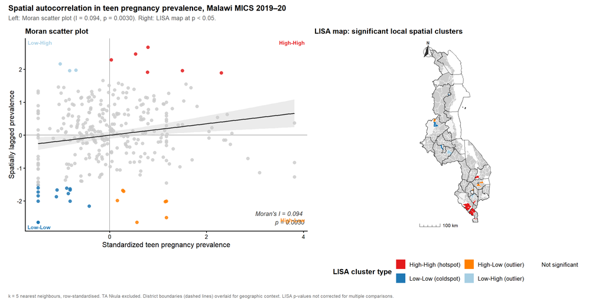

```r
# Step 2: Colors
lisa_cols <- c(
  "High-High (hotspot)" = "#E31A1C",
  "Low-Low (coldspot)"  = "#1F78B4",
  "High-Low (outlier)"  = "#FF7F00",
  "Low-High (outlier)"  = "#A6CEE3",
  "Not significant"     = "grey80"
)

# Step 3: Moran scatter plot
p_moran_scatter <- ggplot(st_drop_geometry(ta_lisa), aes(x = z_prev, y = z_lag)) +
  geom_hline(yintercept = 0, colour = "grey60", linewidth = 0.4) +
  geom_vline(xintercept = 0, colour = "grey60", linewidth = 0.4) +
  geom_point(aes(colour = quadrant, fill = quadrant), shape = 21, size = 2.4, stroke = 0.4, alpha = 0.85) +
  geom_smooth(method = "lm", se = TRUE, colour = "grey20", fill = "grey80", linewidth = 0.8) +
  annotate("text", x = Inf, y = -Inf,
    label = sprintf("Moran's I = %.3f\np = %.4f", moran_perm$statistic, moran_perm$p.value),
    hjust = 1.1, vjust = -0.5, size = 3.5, colour = "grey20", fontface = "italic") +
  annotate("text", x = Inf,  y = Inf,  label = "High-High", hjust = 1.1,  vjust = 1.5,  size = 3, colour = "#E31A1C", fontface = "bold") +
  annotate("text", x = -Inf, y = -Inf, label = "Low-Low",   hjust = -0.1, vjust = -0.5, size = 3, colour = "#1F78B4", fontface = "bold") +
  annotate("text", x = Inf,  y = -Inf, label = "High-Low",  hjust = 1.1,  vjust = -2.2, size = 3, colour = "#FF7F00", fontface = "bold") +
  annotate("text", x = -Inf, y = Inf,  label = "Low-High",  hjust = -0.1, vjust = 1.5,  size = 3, colour = "#A6CEE3", fontface = "bold") +
  scale_colour_manual(values = lisa_cols, guide = "none") +
  scale_fill_manual(values = lisa_cols, guide = "none") +
  labs(title = "Moran scatter plot",
       x = "Standardized teen pregnancy prevalence", y = "Spatially lagged prevalence") +
  theme_classic(base_size = 12) +
  theme(plot.title = element_text(face = "bold", size = 12), panel.grid = element_blank())

## Extract district centroids for labeling (instead of TA labels)
district_labels <- districts %>%
  st_centroid() %>%
  mutate(district_name = GEONAMES)

# Then in the ggplot, replace the two geom_label_repel blocks with:

p_lisa_map <- ggplot() +
  # Base TA boundaries
  geom_sf(data = ta_boundaries_unique, fill = "grey96", colour = "grey75", linewidth = 0.25) +
  # Non-significant TAs in grey
  geom_sf(data = ta_lisa %>% filter(quadrant == "Not significant"),
          fill = "grey80", colour = "white", linewidth = 0.15) +
  # Significant TAs with LISA colors (main clusters)
  geom_sf(data = ta_lisa %>% filter(quadrant != "Not significant"),
          aes(fill = quadrant), colour = "white", linewidth = 0.2) +
  # District boundaries overlay - transparent fill with bold dark border
  geom_sf(data = districts, fill = NA, colour = "#000000", linewidth = 0.2, linetype = "solid", alpha = 0.7) +
  annotation_north_arrow(location = "tl", which_north = "true",
    height = unit(1.0, "cm"), width = unit(1.0, "cm"),
    pad_x = unit(0.2, "cm"), pad_y = unit(0.2, "cm"),
    style = north_arrow_fancy_orienteering(
      text_size = 7, text_face = "bold", line_width = 0.8,
      text_col = "grey20", fill = c("grey20", "white"))) +
  annotation_scale(location = "bl", width_hint = 0.30, text_cex = 0.65,
                   line_width = 0.6, height = unit(0.18, "cm"),
                   pad_x = unit(0.2, "cm"), style = "ticks") +
  scale_fill_manual(name = "LISA cluster type", values = lisa_cols, drop = FALSE) +
  labs(title = "LISA map: significant local spatial clusters") +
  coord_sf(datum = NA) +
  theme_minimal(base_size = 12) +
  theme(panel.grid = element_blank(), axis.title = element_blank(),
        axis.text = element_blank(), axis.ticks = element_blank(),
        legend.position = "bottom", legend.title = element_text(face = "bold"),
        plot.title = element_text(face = "bold", size = 12)) +
  guides(fill = guide_legend(nrow = 2, ncol = 3, override.aes = list(linewidth = 0.4)))

# Step 5: Combine and display
p_lisa_combined <- p_moran_scatter + p_lisa_map +
  plot_annotation(
    title = "Spatial autocorrelation in teen pregnancy prevalence, Malawi MICS 2019–20",
    subtitle = sprintf("Left: Moran scatter plot (I = %.3f, p = %.4f). Right: LISA map at p < 0.05.",
                       moran_perm$statistic, moran_perm$p.value),
    caption = "k = 5 nearest neighbours, row-standardised. TA Nkula excluded. District boundaries (dashed lines) overlaid for geographic context. LISA p-values not corrected for multiple comparisons.",
    theme = theme(plot.title = element_text(face = "bold", size = 13, hjust = 0),
                  plot.subtitle = element_text(size = 10, colour = "grey35", hjust = 0),
                  plot.caption = element_text(size = 8, colour = "grey45", hjust = 0),
                  plot.margin = margin(8, 8, 6, 8))
  ) + plot_layout(widths = c(1, 1))

p_lisa_combined
```

## 16. Save LISA Figure

We exported the combined LISA figure in two formats: a high-resolution PNG (300 dpi) for manuscript submission and a TIFF (600 dpi, LZW compression) for journal requirements. Both files are saved to the working directory.

```r
ggsave(
  "Figure_LISA_Teen_Pregnancy_Malawi_MICS.png",
  plot = p_lisa_combined,
  dpi = 300,
  width = 14,
  height = 7,
  units = "in",
  bg = "white"
)

ggsave(
  "Figure_LISA_Teen_Pregnancy_Malawi_MICS.tiff",
  plot = p_lisa_combined,
  device = "tiff",
  dpi = 600,
  width = 14,
  height = 7,
  units = "in",
  compression = "lzw"
)
```

## 17. Export Spatial Results

We exported the final `ta_lisa` spatial object as a shapefile for use in external GIS software (ArcGIS or QGIS), enabling further cartographic styling, overlay analysis, or reporting. The exported file includes all LISA statistics, cluster classifications, prevalence estimates, and sample size flags.

```r
cat("\n", strrep("=", 80), "\n", sep = "")
cat("EXPORTING RESULTS\n")
```

```
## EXPORTING RESULTS
```

```r
cat(strrep("=", 80), "\n", sep = "")
st_write(
  ta_lisa,
  "ta_lisa_results_with_boundaries.shp",
  delete_dsn = TRUE
)
```

```
## Deleting source `ta_lisa_results_with_boundaries.shp' using driver `ESRI Shapefile'
## Writing layer `ta_lisa_results_with_boundaries' to data source
##   `ta_lisa_results_with_boundaries.shp' using driver `ESRI Shapefile'
## Writing 331 features with 25 fields and geometry type Multi Polygon.
```

```r
cat("Exported: ta_lisa_results_with_boundaries.shp\n")
```

```
## Exported: ta_lisa_results_with_boundaries.shp
```

```r
cat("Use this in ArcGIS or QGIS to map hotspots, coldspots, and prevalence.\n")
```

```
## Use this in ArcGIS or QGIS to map hotspots, coldspots, and prevalence.
```

## 18. Export CSV Results

We exported the non-spatial LISA results as a flat CSV file for use in supplementary tables, secondary analysis, or sharing with co-authors who may not work in R or GIS environments.

```r
write_csv(
  ta_lisa %>% st_drop_geometry(),
  "ta_lisa_results.csv"
)

cat("Exported: ta_lisa_results.csv\n")
```

```
## Exported: ta_lisa_results.csv
```

## 19. Export Summary Statistics

We wrote a plain-text summary report containing the full global Moran’s I test output (asymptotic and permutation), the LISA cluster classification counts, and the hotspot and coldspot TA lists. This file serves as a reproducible record of all key spatial statistics produced by the analysis.

```r
sink("ta_lisa_summary_statistics.txt")

cat("MALAWI MICS 2019–20: TA-LEVEL LISA ANALYSIS OF TEEN PREGNANCY\n")
cat(strrep("=", 80), "\n\n", sep = "")

cat("GLOBAL MORAN'S I TEST:\n")
print(moran_asym)

cat("\n\nPERMUTATION TEST, 999 simulations:\n")
print(moran_perm)

cat("\n\nCLUSTER CLASSIFICATION:\n")
print(table(ta_lisa$cluster_type))

cat("\n\nHOTSPOTS, High-High:\n")
if (nrow(hotspots) > 0) {
  print(hotspots)
} else {
  cat("None detected\n")
}

cat("\n\nCOLDSPOTS, Low-Low:\n")
if (nrow(coldspots) > 0) {
  print(coldspots)
} else {
  cat("None detected\n")
}

sink()

cat("Exported: ta_lisa_summary_statistics.txt\n")
```

```
## Exported: ta_lisa_summary_statistics.txt
```

# PART V: Discussion and Interpretation

## Key Findings: Teenage Pregnancy in Malawi

### Prevalence and Sociodemographic Risk Factors

Among the 5,758 adolescent females (weighted n = 5,538) examined in this analysis, the overall prevalence of teenage pregnancy was 25.5%. Substantial sociodemographic disparities were evident in the descriptive analysis (Table 2), with prevalence ranging from 10.3% among the richest households to 42.8% among the poorest—a 4.2-fold difference. Education was similarly patterned: girls with primary education or lower had a prevalence of 31.5%, compared to 14.7% among those with secondary education or higher, reflecting 2.1-fold disparity. Rural residence carried 1.9 times the prevalence of urban residence (29.6% vs. 15.3%).

The strongest univariable associations with pregnancy (Table 3, Model 1) were current marital status (OR 51.1 for currently married vs. not in union, 95% CI 38.5–67.8), contraceptive use (OR 11.3, 95% CI 7.45–17.1), and wealth index (OR 6.50 for poorest vs. richest, 95% CI 4.86–8.69). These patterns align with demographic expectations: marriage and union formation precede and facilitate childbearing among adolescents; current contraceptive use is a strong marker of prior reproductive experience; and economic hardship (poverty) is a documented risk factor for early pregnancy in low-income settings.

### Adjusted Risk Factor Model

In the multivariable model adjusted for all six sociodemographic exposures (Table 3, Model 2, n = 4,776 unweighted; n = 4,633 weighted), the adjusted odds ratios (aORs) revealed several important patterns:

1. **Wealth gradient persisted:** Compared to the richest quintile, girls in lower wealth quintiles retained significantly elevated risk, with aORs ranging from 2.71 (second quintile, 95% CI 1.45–5.05) to 2.87 (poorest, 95% CI 1.55–5.32). The gradient was remarkably consistent across the four lower quintiles, confirming that poverty-related factors are robust risk drivers even after accounting for education, residence, marital status, contraception, and insurance.
2. **Marital status dominated:** Marriage or co-habitation remained the strongest predictor after adjustment, with aOR 35.3 (95% CI 24.9–50.0) for currently married girls and aOR 40.7 (95% CI 17.9–92.5) for those living with a partner. This reflects the biological reality that marriageability and childbearing are tightly coupled in this setting and that married adolescents are nearly certain to be pregnant or to become pregnant within the marriage.
3. **Education lost statistical significance after adjustment** (aOR 0.77 for secondary or higher vs. primary or lower, 95% CI 0.56–1.06). This suggests that much of education’s protective effect in the crude analysis operates through its correlation with wealth, marital status, or other mediators—a finding worth exploring in future mediation analyses.
4. **Place of residence also became non-significant** (aOR 0.68 for rural vs. urban, 95% CI 0.40–1.17), implying that the rural–urban disparity is largely confounded by differences in wealth, marital patterns, and education across these regions.
5. **Contraceptive use remained strongly associated with pregnancy** (aOR 11.7, 95% CI 7.02–19.5, p < 0.001). However, this association is most naturally interpreted as **reverse causality**: girls who are pregnant or have experienced pregnancy are more likely to adopt contraception to prevent future pregnancy. This variable marks reproductive history rather than a causal risk factor and should not be interpreted as “using contraception increases pregnancy risk.” Its inclusion in the multivariable model provides adjustment for reproductive experience among the unpregnant (those not yet pregnant or no longer pregnant at survey), but causal interpretation is unwarranted.
6. **Health insurance had insufficient precision** to inform policy: only 1 pregnant case was observed among 22 weighted insured adolescents (aOR 0.72, 95% CI 0.11–4.75). The wide confidence interval encompasses both protection and increased risk. This variable adds little information and reflects both the low insurance coverage in the survey and its weak association with pregnancy prevalence in this population. Results should not be interpreted as evidence of insurance protecting against or increasing pregnancy risk.

### Spatial Clustering and Geographic Hotspots

Local Indicators of Spatial Association (LISA) classified the 331 surveyed TAs into five categories: - **6 hotspots** (High-High, spatially significant clusters of above-average prevalence) - **21 coldspots** (Low-Low, spatially significant clusters of below-average prevalence) - **10 outliers** (7 High-Low; 3 Low-High) - **294 not significant**

### Spatial Heterogeneity and Implications for Policy

The identification of a high-prevalence cluster in the Lower Shire suggests that **one-size-fits-all national approaches to adolescent sexual and reproductive health may be insufficient**. Targeted interventions—including enhanced reproductive health education, improved contraceptive access, economic opportunity expansion for girls, and marriage postponement programming—may be particularly impactful if concentrated in high-prevalence TAs and neighboring regions.

Conversely, coldspots (predominantly urban administrative units with zero or near-zero prevalence in the survey) may offer comparative examples of protective factors to study and potentially scale.

### Limitations

1. **Small sample sizes in spatial units:** Many TAs had fewer than 20 teen respondents (some fewer than 5), limiting the precision of prevalence estimates and the stability of LISA classifications. Estimates for very-small-sample TAs should be interpreted as preliminary or flagged for future rounds of larger-scale surveillance.
2. **Cross-sectional design:** This analysis cannot establish causality. The associations observed in Table 3, particularly for contraceptive use, are subject to reverse causality and other confounding not measured in the MICS (e.g., age at sexual debut, partner age, access to family planning, community-level norms).
3. **GPS jittering:** Cluster coordinates in the MICS are jittered (+/- 2–10 km urban, +/- 5 km rural) for confidentiality, which can introduce noise into spatial analyses. TAs with few clusters may be more sensitive to this jitter.
4. **Missing data:** While item-level missingness was low (<2%), six girls (0.1%) were excluded due to missing age or pregnancy status. Complete-case analysis in the multivariable model (n = 4,776) excludes girls with missing data on any covariate; patterns of missingness by wealth or education were not formally examined.
5. **Unmeasured confounding:** The MICS does not include information on girls’ age at sexual debut, partner age, access to and quality of reproductive health services, community and religious norms about early marriage and childbearing, or intergenerational transmission of early pregnancy. These factors may be important mediators or confounders.
6. **Health insurance prevalence:** Only 0.4% of adolescent respondents reported health insurance, limiting statistical power and generalizability of insurance-related estimates.

### Strengths

- **Complex survey design properly accounted for** via two-stage stratified cluster sampling specification in the `survey` package, ensuring estimates are representative of the adolescent population aged 15–19 in Malawi.
- **Survey-weighted and internally consistent analysis:** All prevalence, regression, and spatial analyses used the same weighting scheme and complete-case sample, avoiding discrepancies between tables.
- **Convergent spatial evidence:** Both asymptotic and permutation Moran’s I tests confirm clustering, increasing confidence in the spatial signal.
- **Transparent reference categories and model specification:** All reference categories are pre-specified, reported, and held constant across tables, facilitating reproducibility and policy communication.

## 20. Save R Workspace

We saved the complete R workspace to an `.RData` file so that all objects — spatial weights, survey designs, prevalence estimates, and LISA results — can be reloaded in future sessions without re-running the full analysis pipeline.

```r
save.image("ta_lisa_analysis_with_boundaries.RData")

cat("Saved: ta_lisa_analysis_with_boundaries.RData\n")
```

```
## Saved: ta_lisa_analysis_with_boundaries.RData
```

## 21. Analysis Complete

This chunk prints a completion message and a checklist of recommended next steps for post-processing and reporting. All analytical outputs — tables, figures, shapefiles, and summary statistics — are saved to the working directory.

```r
cat("\n", strrep("=", 80), "\n", sep = "")
cat("ANALYSIS COMPLETE\n")
```

```
## ANALYSIS COMPLETE
```

```r
cat(strrep("=", 80), "\n", sep = "")
cat("\nNext steps:\n")
```

```
##
## Next steps:
```

```r
cat("1. Open ArcGIS or QGIS.\n")
```

```
## 1. Open ArcGIS or QGIS.
```

```r
cat("2. Load ta_lisa_results_with_boundaries.shp.\n")
```

```
## 2. Load ta_lisa_results_with_boundaries.shp.
```

```r
cat("3. Style by cluster_type to visualize hotspots and coldspots.\n")
```

```
## 3. Style by cluster_type to visualize hotspots and coldspots.
```

```r
cat("4. Or style by prev_pct to show the prevalence gradient.\n")
```

```
## 4. Or style by prev_pct to show the prevalence gradient.
```